# Bayesian Data Analysis, Part 1

Clay Ford

2026-02-06

## Agenda

- Conceptual overview of basic Bayesian data analysis
- How to run a Bayesian analysis using the `rstanarm` package
- How to assess convergence and model fit
- How to work with posterior distributions

## Motivating example

Estimate the mean weight of students’ backpacks at UVA.

- Take a random sample of 100 students
- Weigh their backpacks in lbs.
- I calculate the mean to be 16.1 lbs.

It’s just an estimate. If I take another sample, I’ll get a different estimate. Say 19.1. Or 16.8. I want to understand the uncertainty in my estimate.

## The traditional approach

Assume there is some fixed but unknown mean backpack weight. If we could see all and know all, we could estimate the “true” mean. We want to estimate that true mean.

- Use 16.1 as our estimated mean<sup>1</sup>
- calculate a 95% confidence interval: (15.2, 16.9)
- We might say we’re 95% confident the true mean is between 15.2 and 16.9

If we were to repeat this process many, many times, 95% of the confidence intervals would contain the true value. (NOTE: A confidence interval is NOT a probability interval.)

This approach is sometimes called the **Frequentist** approach.

[^1]: We also have to estimate the standard deviation in order to calculate the traditional confidence interval.

## The Bayesian approach

Instead of estimating some “true” mean, we instead estimate the *probability distribution* of possible means.

- begin with a *prior* distribution of how we believe the means are distributed
- update the prior distribution using the data we collected to obtain a *posterior* distribution using *Bayes’ theorem*
- use the posterior distribution to describe the mean of students’ backpacks

**The “estimate” is the *entire* posterior distribution.**

## Example of a prior distribution

Prior to our analysis, perhaps we think the average backpack weighs around 18 lbs<sup>1</sup>. A possible prior distribution might be a $N(18, 5)$.

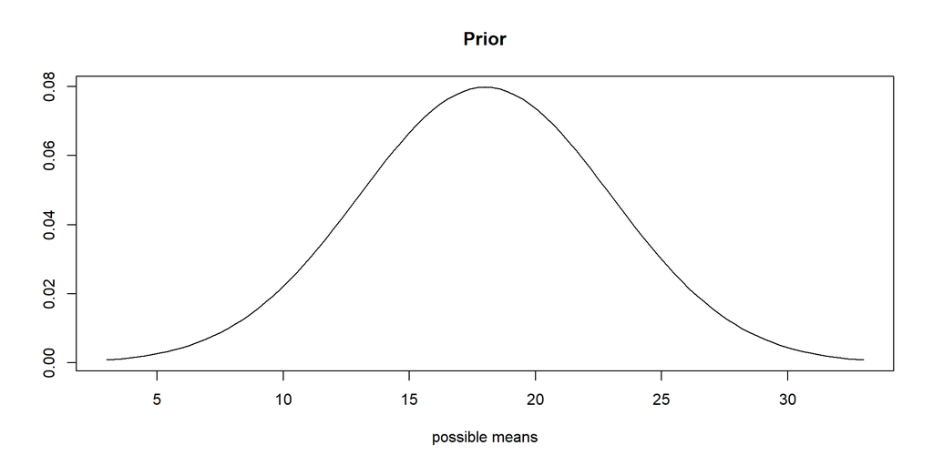

[^2]: https://well.blogs.nytimes.com/2009/07/21/weighing-school-backpacks/

## Example of a posterior distribution

After observing our data we use *Bayes’ theorem* to update our prior distribution to get a posterior distribution.

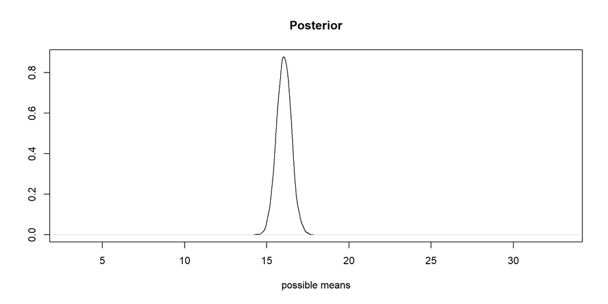

## Example of using posterior distribution

There’s about 95% probability that the mean backpack weight is between 15.2 and 16.9 lbs.

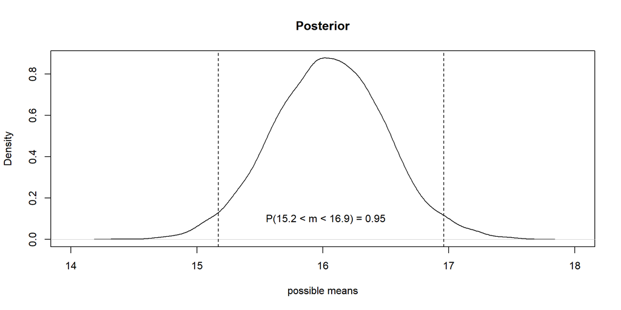

## Bayes’ theorem in words

We use Bayes’ theorem to update our prior distribution to get a posterior distribution.

$$\text{posterior} = \frac{\text{likelihood} \times \text{prior}}{\text{average likelihood}}$$

- prior is how we believe a *parameter* of interest is distributed, represented by a probability distribution. Eg: $\text{weight} \sim N(18,5)$
- likelihood is the probability of observed data *given* a certain parameter, also represented by a probability distribution. Eg: $\text{weight}_i \sim N(\mu, \sigma)$
- posterior is the updated prior
- average likelihood ensures the posterior is a distribution with area that sums to 1

## Using Bayes’ theorem in real life

- Using Bayes’ theorem mathematically is impractical for all but the simplest problems
- Instead we use something called *Markov chain Monte Carlo (MCMC)*
- MCMC draws samples from the posterior distribution
- This requires computing time, sometimes lots of time
- The goal today is show you how to do this in R using the `rstanarm` package

## The `rstanarm` package

- R + Stan + arm
  - Stan: platform for statistical modeling
  - arm: applied regression modeling
- *“The primary target audience is people who would be open to Bayesian inference if using Bayesian software were easier but would use frequentist software otherwise.”*
- Allows us to specify Bayesian models using traditional R modeling syntax
- `rstanarm` generates Stan code for us, and then uses the `rstan` package to run the model

## Traditional approach: backpack data

Estimate the mean and calculate a confidence interval using `t.test()`

```r
t.test(dat$backpacks)
```

```
    One Sample t-test

data:  dat$backpacks
t = 37.061, df = 99, p-value < 2.2e-16
alternative hypothesis: true mean is not equal to 0
95 percent confidence interval:
 15.1907 16.9093
sample estimates:
mean of x
    16.05
```

## Traditional approach: backpack data

We can also analyze the backpack data using an intercept-only linear model:

```r
mod1 <- lm(backpacks ~ 1, data = dat)
```

The intercept-only model:

$$\text{weight}_i \sim N(\mu, \sigma)$$

Where $\mu$ is the intercept and $\sigma$ is the residual standard error.

*This is an important concept because doing Bayesian statistics requires us to frame our analysis as a model.*

## Traditional approach: backpack data

```r
summary(mod1)
```

```
Call:
lm(formula = backpacks ~ 1, data = dat)

Residuals:
   Min     1Q Median     3Q    Max
-9.050 -2.100 -0.100  1.475 24.950

Coefficients:
            Estimate Std. Error t value Pr(>|t|)
(Intercept)  16.0500     0.4331   37.06   <2e-16 ***
---
Signif. codes:  0 '***' 0.001 '**' 0.01 '*' 0.05 '.' 0.1 ' ' 1

Residual standard error: 4.331 on 99 degrees of freedom
```

The intercept-only model estimates a mean of 16.05 and a standard deviation of 4.331.

## Traditional approach: backpack data

We can also extract a confidence interval from the intercept-only model:

```r
confint(mod1)
```

```
              2.5 %  97.5 %
(Intercept) 15.1907 16.9093
```

This matches what we get with the `t.test()` function.

```r
t.test(dat$backpacks)$conf.int
```

```
[1] 15.1907 16.9093
attr(,"conf.level")
[1] 0.95
```

## Traditional approach: backpack data

In addition to `lm`, we can use `glm` with `family = gaussian`. GLM = Generalized Linear Model.

```r
mod1 <- glm(backpacks ~ 1, data = dat,
            family = gaussian)
confint(mod1)
```

```
  2.5 %  97.5 %
15.2012 16.8988
```

Same model as before:

“Gaussian” is another name for “normal”. Need to specify Gaussian because a GLM can fit many different *families* of models (eg, Poisson, Binomial, Gamma)

## Bayesian approach: backpack data

Using rstanarm, we can perform a Bayesian analysis using code that is almost identical to the analysis performed with `glm()`.

```r
library(rstanarm)
bm1 <- stan_glm(backpacks ~ 1, data = dat,
                  family = gaussian,
                  prior_intercept = normal(18, 5))
```

Instead of a confidence interval we obtain a Bayesian uncertainty interval:

```r
posterior_interval(bm1, prob = 0.95,
                   pars = "(Intercept)")
```

```
                2.5%    97.5%
(Intercept) 15.17081 16.96359
```

## Prior distributions

- Bayesian Data Analysis requires we provide prior distributions.
- Seems burdensome but it allows us to incorporate prior knowledge into our model.
- Is there a “correct” prior? No. But some are better than others.
- Different but reasonable priors will often lead to the same basic conclusion.
- We can vary priors and repeat the analysis to to see how different states of initial information influence the outcome.
- The smaller the sample size, the larger the effect a prior will have on the inference.

## Prior distributions in `rstanarm`

- `rstanarm` provides *weakly informative* priors by default. (ie, rules out extreme positive or negative values)
- *Uninformative priors* place equal weight on all possible values (not recommended)
- Using the default priors usually leads to similar results obtained by traditional modeling
- To see the priors, call the `prior_summary()` function on the model object

Let’s go to the R script and work some examples.

## Checking sampling quality

When doing Bayesian data analysis with MCMC sampling, we want to confirm that the sample we obtained describes the posterior.

We should do this before interpreting results and making inferences.

There are several diagnostics that can help with this.

Thankfully `rstanarm` provides warnings when sampling is suspect.

## Visual assessment of convergence

- MCMC uses *Markov chains* to explore the shape of the posterior distribution
- `rstanarm` runs 4 chains by default. Can think of these as 4 expeditions to explore the posterior.
- We want these chains to converge to the same distribution
- We can visually assess with a *trace plot*

```r
plot(stan_mod, plotfun = "trace", pars = "var_name")
```

We hope to see the chains indistinguishable from one another

## Example of trace plot showing convergence

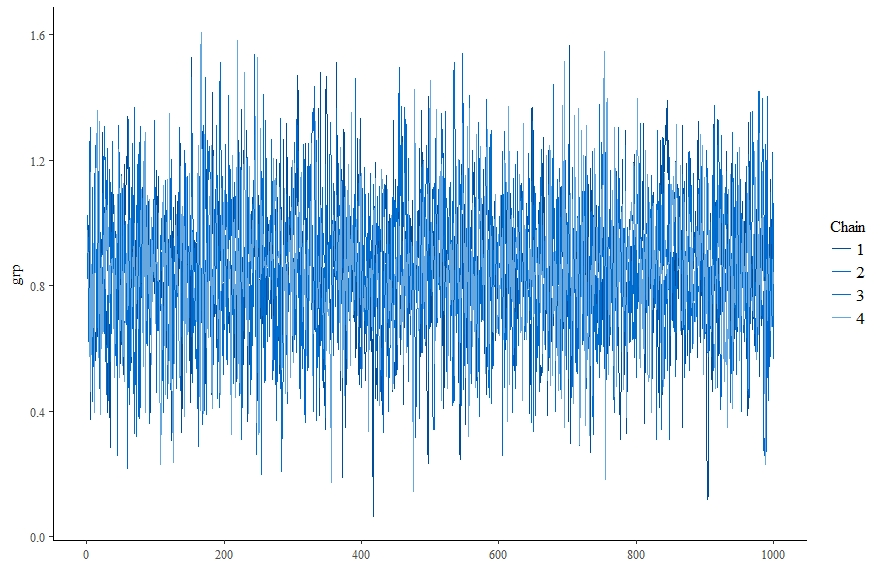

## Example of trace plot showing non-convergence

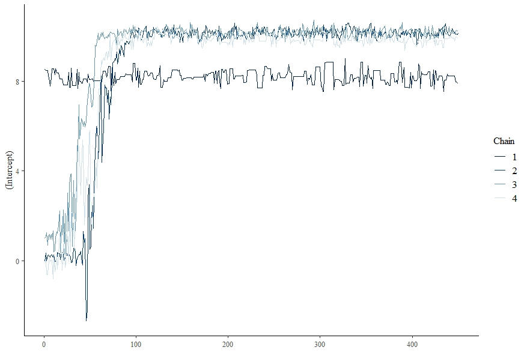

## Numerical assessment of convergence (`Rhat`)

- The $\hat{R}$ statistic compares variation between the chains to the variation within chains
- If all chains converge to the same region, then $\hat{R}$ should be close to 1
- If $\hat{R} < 1.1$ we have good, though not infallible, evidence of convergence
- Each posterior distribution will have a separate $\hat{R}$ statistic
- We would like them all less than 1.1
- Included in the `summary` output of the model in the “MCMC diagnostics” section

## Dealing with convergence issues

- If the Markov chains do not converge, you’ll get a warning that says “`Markov chains did not converge! Do not analyze results!`”
- This can sometimes be resolved by increasing the number of iterations using the `iter` argument.
- Example, increase from 2000 to 4000:

```r
stan_glm(y ~ grp, data = bat, family = gaussian,
         iter = 4000)
```

## Effective sample size (`n_eff`)

- MCMC sampling is not independent and can exhibit autocorrelation
- The Effective Sample Size (`n_eff`) corrects for any autocorrelation and approximates the number of independent samples we have
- We’d like to see `n_eff` > 1000
- Included in the `summary` output of the model in the “MCMC diagnostics” section
- Each of the 4 chains is run for 2000 iterations, with the first 1000 as a “warm-up”
- “warm-up” iterations are discarded
- This means we have $4 \times 1000 = 4000$ total samples
- `n_eff` is the approximate number of independent samples

## Posterior predictive checking (PPC)

- Does our model adequately fit the data?
- PPC simulates data according to our fitted model and compares simulated data to observed data
- A good fitting model should replicate features of the observed data
- A visual check: `pp_check(stan_mod)`

## Example of a PPC graph

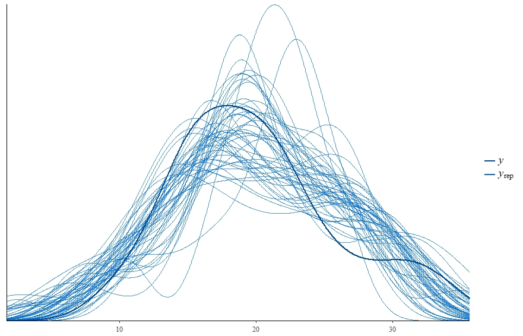

Let’s return to the R script.

## Summarizing and interpreting results

Once we have assessed the sampling quality and model fit, we’re ready to summarize and interpret the posterior distributions.

Common summaries include:

- point estimates
- posterior intervals
- posterior standard deviations

## Point estimates

- These are usually the mean or median of a posterior distribution.
- Both mean and median are provided in the `summary` of a model fit with `rstanarm`
- Just one incomplete summary of the posterior distribution
- Point estimates should be provided with additional information, such as posterior intervals

## Posterior intervals

- These are the range of possible parameter values stated in terms of probability
- Example: a 95% posterior interval of (0.4, 1.3) is interpreted to mean that there is 95% probability the parameter is between 0.4 and 1.3
- 80% posterior intervals are provided by default when calling `summary()` on a model object
- 90% posterior intervals are provided by default when using `posterior_interval()`
- According to the `posterior_interval()` documentation: “90% intervals are more stable than 95% intervals”
- You can use the `probs` or `prob` arguments to request different intervals. Say you have a model object named “m” and want 95% intervals:
  - `summary(m, probs = c(0.025, 0.975))`
  - `posterior_interval(m, prob = c(0.025, 0.975))`

## Posterior standard deviations

- These summarize the spread of the posterior distribution
- Probably not useful if a posterior distribution is skewed
- Also provided in the `summary` output

## Posterior distributions revisited

Things to keep in mind:

- We have one posterior distribution for each parameter in our model
- The posterior distributions are the result of MCMC sampling; each posterior distribution we obtain is actually a sample
- The default “sample size” in `rstanarm` is 4000 (4 chains at 2000 iterations each, with first 1000 as a warm-up)
- The `summary` output in `rstanarm` summarizes these samples from the posterior distributions

## Working directly with posterior distributions

We can create our own summaries of the posterior distributions.

The `as.matrix()` and `as.data.frame()` functions extract the posterior samples into a matrix and data frame, respectively.

Let’s say we want to estimate the probability that the mean backpack weight is greater than 16 lbs. Notice we specify the `(Intercept)` parameter with the `$` operator. That’s because there are two parameters to choose from (`Intercept` and `sigma`)

```r
post_samp <- as.data.frame(bmod1)
mean(post_samp$`(Intercept)` > 16)
```

```
[1] 0.544
```

## Working directly with posterior distributions

Let’s say we want to estimate the probability that the difference in battery life is greater than 1 hour. Notice we specify the `grp` parameter with the `$` operator. That’s because there are three parameters to choose from (`Intercept`, `grp`, and `sigma`)

```r
post_samp2 <- as.data.frame(bm.out)
mean(post_samp2$grp > 1)
```

```
[1] 0.28475
```

## Working directly with posterior distributions

Let’s say we want to create 95% posterior intervals for the means of the two brands of batteries. The `Intercept` is the estimated mean of grp 0. The sum of the `Intercept` and `grp` coefficient is the estimated mean of grp 1.

```r
quantile(post_samp2$`(Intercept)`,
         probs = c(0.025, 0.975))
```

```
    2.5%    97.5%
 9.82601 10.49629
```

```r
quantile(post_samp2$`(Intercept)` + post_samp2$grp,
         probs = c(0.025, 0.975))
```

```
    2.5%    97.5%
10.69355 11.35564
```

Let’s return to the R script.

## Some journal articles using `rstanarm`

- Espe, M. et al. (2016) Yield gap analysis of US rice production systems shows opportunities for improvement. *Field Crops Research*, 196:276-283.
- Kubrak, O. et al. (2017) Adaptation to fluctuating environments in a selection experiment with Drosophila melanogaster. *Ecology and Evolution*, 7:3796-3807.
- Herzog, S. et al. (2017) Sun Protection Factor Communication of Sunscreen Effectiveness. *JAMA Dermatology*, 153(3):348-350.
- Kovic, M. and Hänsli, N. (2017) The impact of political cleavages, religiosity, and values on attitudes towards nonprofit organizations. *Social Sciences*, 7(1), 2.
- Schnase, J. L., Carroll, M. L., Montesano, P. M., & Seamster, V. A. (2025, September 1). Shifts in breeding phenology for Cassin’s Sparrow (Peucaea cassinii) over four decades. *Journal of Field Ornithology*, 96(3), 1 - 11. Retrieved from https://doi.org/10.5751/JFO-00691-960303.

## References

- Betancourt, Michael. (2018) *A Conceptual Introduction to Hamiltonian Monte Carlo*. https://arxiv.org/pdf/1701.02434.pdf
- Gelman, A., Hill, J, & Vehtari, A. (2020) *Regression and Other Stories*. Cambridge University Press. https://avehtari.github.io/ROS-Examples/
- Goodrich B, Gabry J, Ali I & Brilleman S. (2025). rstanarm: Bayesian applied regression modeling via Stan. R package version 2.32.2 https://mc-stan.org/rstanarm.
- McElreath, M. (2020). *Statistical Rethinking, 2nd Ed*. CRC Press. Boca Raton.
- Muth, C., Oravecz, Z., & Gabry, J. (2018). User-friendly Bayesian regression modeling: A tutorial with rstanarm and shinystan. *The Quantitative Methods for Psychology*, 14(2), 99-119. doi:10.20982/tqmp.14.2.p099
- Theoretical Ecology. (2010, September 17). Metropolis-Hastings MCMC in R. https://theoreticalecology.wordpress.com/2010/09/17/metropolis-hastings-mcmc-in-r/

## Thanks for coming

- For free statistical consulting, contact us: `statlab@virginia.edu`
- Sign up for more workshops or see past workshops:  
  https://library.virginia.edu/data/training
- Register for the Research Data Services newsletter to be notified of new workshops:  
  https://library.virginia.edu/data/newsletters